# Course Project 1 For Reproducible Research

## **Loading and preprocessing the data**

Show any code that is needed to  
1. Load the data (i.e., read.csv()).  
2. Process/transform the data (if necessary) into a format suitable for your analysis.

```r
#Load the appropriate libraries.
library(ggplot2)


#Set the directory and file names.
directory <- "/Users/brettaddison/Dropbox/Coursera_data_science/Reproducible_Research/Week1/project/"
html_file_loc <- 'https://d396qusza40orc.cloudfront.net/repdata%2Fdata%2Factivity.zip'
activity_data_zipfile <- paste0(directory, 'repdata-data-activity.zip')

#Download required activities file.
download.file(html_file_loc, activity_data_zipfile, method = 'curl')

#Unzip file.
activity_file <- unzip(activity_data_zipfile, exdir = directory)

#Read in unzipped activity data file.
activity_data_raw <- read.csv(activity_file, header = TRUE)
```

## **What is the mean total number of steps taken per day?**

For this part of the assignment, you can ignore the missing values in the dataset.

1. Calculate the total number of steps taken per day.
2. If you do not understand the difference between a histogram and a barplot, research the difference between them. Make a histogram of the total number of steps taken each day.
3. Calculate and report the mean and median of the total number of steps taken per day.

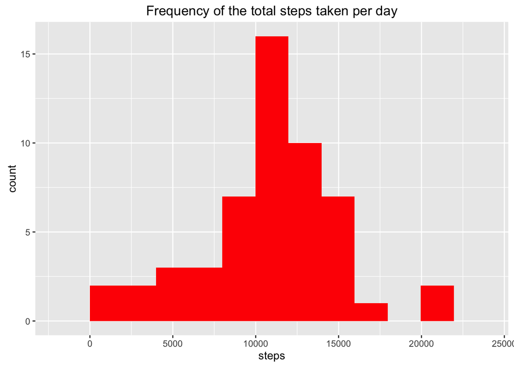

```r
#Calculate the total number of steps taken per day (ignoring missing values).
#Sum by day using aggregate function. Missing values are ignored which will cause dates with all missing values
#to be removed from the dataframe!
activity_step_total <- aggregate(steps ~ date, data = activity_data_raw, FUN = "sum", na.rm=TRUE)


#Create a histogram of the total number of steps taken each day.
ggplot(data=activity_step_total, aes(steps)) + geom_histogram(fill='red', bins=length(activity_step_total$steps)/5)  +
  ggtitle("Frequency of the total steps taken per day")
```

```r
#Calculate the mean and median of the total number of steps taken per day.
mean_steps = mean(activity_step_total$steps)
print(paste0("Mean number of total steps taken per day: ", mean_steps))
```

```
## [1] "Mean number of total steps taken per day: 10766.1886792453"
```

```r
median_steps = median(activity_step_total$steps)
print(paste0("Median number of total steps taken per day: ", median_steps))
```

```
## [1] "Median number of total steps taken per day: 10765"
```

**Mean number of total steps taken per day:** 10766.2  
**Median number of total steps taken per day:** 10765

## **What is the average daily activity pattern?**

1. Make a time series plot (i.e., type = “l”) of the 5-minute interval (x-axis) and the average number of steps taken, averaged across all days (y-axis).
2. Which 5-minute interval, on average across all the days in the dataset, contains the maximum number of steps?

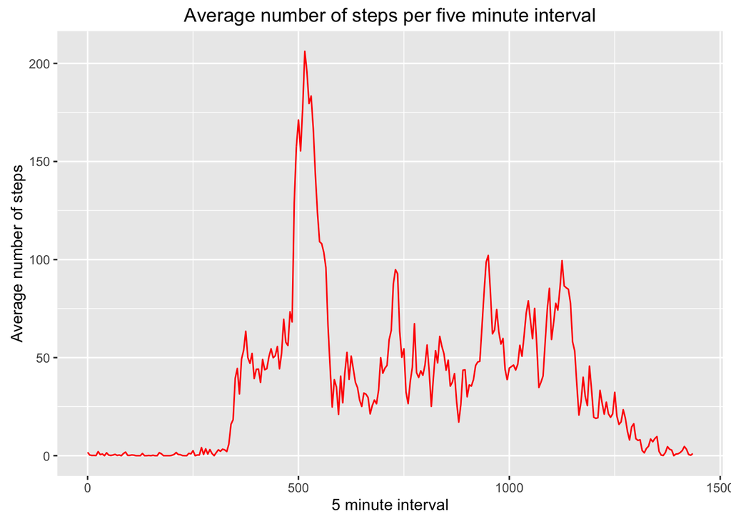

```r
#Convert the interval time to just minutes. The current format (0000) is based on the 24 hour timescale
#i.e., hh:mm.
activity_data_raw_modulus <- activity_data_raw
for (i in 1:length(activity_data_raw_modulus$interval))
{
  activity_data_raw_modulus$interval[i] <- activity_data_raw_modulus$interval[i] -
                                           ((45*floor(activity_data_raw_modulus$interval[i]/100)) -
                                           floor(activity_data_raw_modulus$interval[i]/100)*5)
}

#Calculate the average number of steps for each five minute interval (ignoring missing values).
#Average by interval using aggregate function.
activity_data_interval_ave <- aggregate(steps ~ interval, data = activity_data_raw_modulus, FUN = "mean", na.rm=TRUE)

#Create a time series plot of the average number steps taken for each of the five minute intervals.
ggplot(data=activity_data_interval_ave, aes(x=interval, y=steps)) + geom_line(col='red')  +
ggtitle("Average number of steps per five minute interval") + xlab("5 minute interval") + ylab("Average number of steps")
```

```r
#Which 5-minute interval, averaged across all the days, contains the maximum number of steps?
#Use maximum function.
max_value <- max(activity_data_interval_ave$steps)
print(paste0("The maximum average step value is: ", max_value))
```

```
## [1] "The maximum average step value is: 206.169811320755"
```

```r
where_max_value <- which.max(activity_data_interval_ave$steps)
print(paste0("The location of the maximum average step value: ", where_max_value))
```

```
## [1] "The location of the maximum average step value: 104"
```

```r
max_value_interval <- activity_data_interval_ave$interval[where_max_value]
print(paste0("The interval of the maximum average step value: ", max_value_interval))
```

```
## [1] "The interval of the maximum average step value: 515"
```

**The maximum average step value is:** 206.2  
**The location of the maximum average step value:** 104  
**The interval of the maximum average step value:** 515

## **Imputing missing values**

Note that there are a number of days/intervals where there are missing values (coded as NA). The presence of missing days may presence of missing days may introduce bias into some calculations or summaries of the data.

1. Calculate and report the total number of missing values in the dataset (i.e. the total number of rows with NAs).
2. Devise a strategy for filling in all of the missing values in the dataset. The strategy does not need to be sophisticated. For example, you could use the mean/median for that day, or the mean for that 5-minute interval, etc.
3. Create a new dataset that is equal to the original dataset but with the missing data filled in.
4. Make a histogram of the total number of steps taken each day and Calculate and report the **mean** and **median** total number of steps taken per day. Do these values differ from the estimates from the first part of the assignment? What is the impact of imputing missing data on the estimates of the total daily number of steps?

My strategy for filling in all of the missing values was to use the mean value for the 5-minute intervals.

```r
#Determine the number of NAs in the data.
num_na <- sum(is.na(activity_data_raw$steps))
print(paste0("The number of NAs in the dataset: ", num_na))
```

```
## [1] "The number of NAs in the dataset: 2304"
```

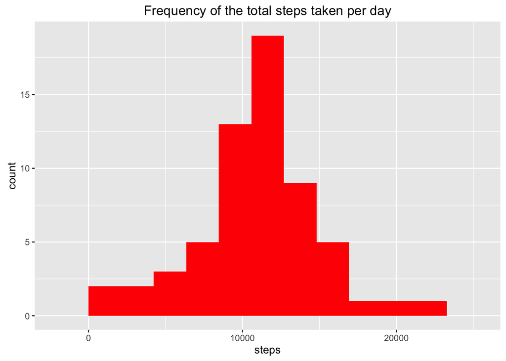

```r
#The strategy I propose for filling the NAs is to use the mean of each particular 5-minute interval.
interval_list <- unique(activity_data_raw_modulus$interval)

#Now we will loop through the different intervals and check each date for missing step values.
#Missing values will be filled with the corresponding median value.
activity_data_modulus_no_NA <- activity_data_raw_modulus
for (i in 1:length(interval_list))
{
  for (j in 1:length(activity_data_raw_modulus$interval))
  {
    if (is.na(activity_data_raw_modulus$steps[j]) && activity_data_raw_modulus$interval[j] == interval_list[i])
    {
      #Replace the NAs if the particular step in the dataset has an NA and the interval at the step
      #matches the interval_list. Rounding steps to the nearest whole number.
      activity_data_modulus_no_NA$steps[j] <- round(activity_data_interval_ave$steps[i])
    }
  }
}

activity_data_modulus_no_NA$steps <- as.numeric(activity_data_modulus_no_NA$steps)

activity_step_total_no_NA <- aggregate(steps ~ date, data = activity_data_modulus_no_NA, FUN = "sum", na.rm=TRUE)

#Create a histogram of the total number of steps taken each day with NAs replaced.
ggplot(data=activity_step_total_no_NA, aes(steps)) + geom_histogram(fill='red', bins=10)  +
  ggtitle("Frequency of the total steps taken per day")
```

```r
#Calculate the mean and median of the total number of steps taken per day.
mean_steps_no_NA = mean(activity_step_total_no_NA$steps)
print(paste0("Mean number of total steps taken per day: ", mean_steps_no_NA))
```

```
## [1] "Mean number of total steps taken per day: 10765.6393442623"
```

```r
median_steps_no_NA = median(activity_step_total_no_NA$steps)
print(paste0("Median number of total steps taken per day: ", median_steps_no_NA))
```

```
## [1] "Median number of total steps taken per day: 10762"
```

**The number of NAs in the dataset:** 2304  
**Mean number of total steps taken per day with NAs imputed:** 10765.6  
**Median number of total steps taken per day with NAs imputed:** 10762

The mean and median values only change slightly (10766.2 and 10765, for mean and median respectively, with just removing NAs).

## **Are there differences in activity patterns between weekdays and weekends?**

For this part the weekdays() function may be of some help here. Use the dataset with the filled-in missing values for this part.

1. Create a new factor variable in the dataset with two levels – “weekday” and “weekend” indicating whether a given date is a weekday or weekend day.
2. Make a panel plot containing a time series plot (i.e. type=“l”) of the 5-minute interval (x-axis) and the average number of steps taken, averaged across all weekday days or weekend days (y-axis). See the README file in the GitHub repository to see an example of what this plot should look like using simulated data.

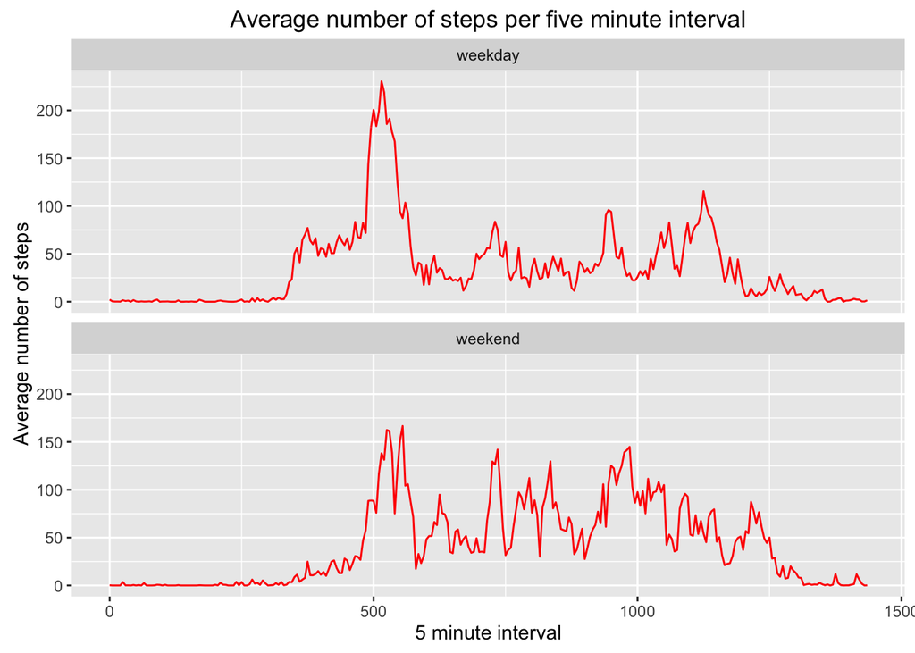

```r
#Compare activity levels between weekdays and weekends.
#Convert the date column in dateset with NAs replaced.
activity_data_modulus_no_NA$date <- as.Date(activity_data_modulus_no_NA$date)

#Create new factor with day of the week.
activity_data_modulus_no_NA$day <- weekdays(activity_data_modulus_no_NA$date)

#Create new factor indicating whether the day is a weekday or weekend.
weekdays <- c('Monday', 'Tuesday', 'Wednesday', 'Thursday', 'Friday')

#Check if day matches the weekdays vector. If it does, then the day is a weekday.
#Otherwise the day is a weekend.
activity_data_modulus_no_NA$day_type <- c('weekend', 'weekday')[(activity_data_modulus_no_NA$day %in% weekdays)+1L]

#Calculate the average number of steps for each five minute interval for weekdays and weekends.
#Average by interval using aggregate function.
activity_data_interval_ave_day_type <- aggregate(steps ~ interval + day_type, data = activity_data_modulus_no_NA, FUN = "mean", na.rm=TRUE)

#Create a time series plot of the average number steps taken for each of the five minute intervals for weekdays and weekends.
ggplot(data=activity_data_interval_ave_day_type, aes(x=interval, y=steps)) + geom_line(col='red')  +
  ggtitle("Average number of steps per five minute interval") + xlab("5 minute interval") + ylab("Average number of steps") +
  facet_wrap(~ day_type, ncol=1)
```

The plot does indicate that there are differences in the average number of steps taken for each 5-minute interval between weekdays and weekends. There appears to be a large spike in the number of steps in the early morning during the weekdays, but this is not seen so much in during the weekends. The number of steps throughout the day during the weekend appear to be higher than on weekdays.